# Domanda Aggregata di Latte

Mattia Albertini

3/14/2025

## Descrizione

Questo R-Studio Script carica e genera le domande individuali di latte riportate dagli studenti durante la lezione di Microeconomia A. Calcoliamo poi la domanda aggregata e la rappresentiamo graficamente.

Nota Bene: Questo è un ambiente dinamico di R chiamoto “R markdown”. Permette di includere blocchi di testo, equazioni, e code chunk come questo,

```
## [1] "hello world"
```

nello stesso documento.

## Set Up

Prima installiamo i pacchetti: estensioni di R che scarichiamo dal web che forniscono funzionalità aggiuntive, come per esempio la funzione per importare i dati da Excel ad R.

Prima installa i paccketti togliendo “#” dal comando install.packages(“package_name”). Poi compila le libraries (attiva i pacchetti richiesti).

```r
# Installa
#install.packages("tidyverse")
#install.packages("magrittr")
#install.packages("readxl")
#install.packages("cowplot")

# Attiva
library(tidyverse)
library(magrittr)
library(readxl)  # to upload from excel
library(cowplot) # to combine plots
```

Ora dobbiamo imporre una “directory” ovvero i luogo in cui tutti gli input e gli output di questa sessione di R andranno a finire.

Senza entrare troppo nel dettaglio, dobbiamo rimpiazzare la scritta verde dentro “wd” con la directory dove tieni i tuoi dati.Per rovarla seleziona i dati dal tuo pc, clicca su “Ottieni Informazioni” (Mac) oppure “Propietà” (Windows) e copia ed incolla quello che c’è scritto alla voce “Situato in” (Mac) oppure “Location” (Windows).

```r
wd <- '/Users/mattiaalbertini/Library/CloudStorage/OneDrive-USI/Microeconomia A/Slides_Mattia/2025/04_Milk_demand/2025'

setwd(wd)
```

Infine, carichiamo i dati usando la funzione read_excel dal pacchetto readxl,

```r
milk <- read_excel("Domanda.xlsx", sheet = 1)
```

I dati dovrebbero essere alla tua destra alla voce “Data”.

## Domande Individuali

Diamo una occhiata ai dati che abbiamo caricato,

| P | Q1 | Q2 | Q3 | Q4 | Q5 | Q6 | Q7 | Q8 | Q9 | Q10 | Q11 | Q12 | Q13 | Q14 | Q15 | Q16 | Q17 | Q18 | Q19 | Q20 | Q21 | Q22 | Q23 | Q24 | Q25 | Q26 | Q27 | Q28 | Q29 | … |
| --- | --- | --- | --- | --- | --- | --- | --- | --- | --- | --- | --- | --- | --- | --- | --- | --- | --- | --- | --- | --- | --- | --- | --- | --- | --- | --- | --- | --- | --- | --- |
| 6.0 | 0 | 0 | 0 | 0 | 1 | 0 | 0 | 0 | 0 | 0 | 0 | 0 | 2 | 0 | 0 | 1 | 0 | 0 | 0 | 0 | 0 | 0 | 0 | 0 | 0 | 0 | 0.0 | 0.0 | 0 | … |
| 4.0 | 0 | 0 | 0 | 0 | 2 | 0 | 0 | 1 | 0 | 0 | 0 | 0 | 3 | 0 | 0 | 1 | 1 | 0 | 0 | 0 | 0 | 0 | 0 | 1 | 1 | 0 | 0.0 | 0.0 | 0 | … |
| 2.0 | 2 | 2 | 0 | 1 | 3 | 1 | 1 | 3 | 1 | 2 | 0 | 0 | 7 | 1 | 0 | 1 | 1 | 0 | 0 | 0 | 1 | 0 | 0 | 2 | 2 | 1 | 1.0 | 0.5 | 1 | … |
| 1.0 | 4 | 2 | 0 | 2 | 4 | 2 | 1 | 4 | 2 | 4 | 2 | 0 | 7 | 2 | 0 | 1 | 1 | 0 | 0 | 0 | 3 | 0 | 2 | 3 | 2 | 2 | 1.5 | 0.5 | 3 | … |
| 0.5 | 5 | 2 | 0 | 5 | 5 | 2 | 2 | 6 | 4 | 5 | 4 | 0 | 7 | 4 | 0 | 1 | 1 | 0 | 0 | 0 | 3 | 0 | 5 | 5 | 2 | 3 | 3.0 | 0.5 | 3 | … |

La prima colonna è quella dei prezzi, le altre colonne sono le vostre quantità che avete riportato per ogni livello di prezzo.

```r
cor(milk$P, milk$Q5)
```

```
## [1] -0.9707253
```

ovviamente una correlazione negativa.

Ora grafichiamo alcune domande individuali. Per semplicità ne ho scelte io 4 interessanti, ma potete cambiare alla voce geom_line() di ogni domanda individuale il valore di x=Q_n, per esempio se volestre graficare la domanda $10$ sostituite per esempio scrivete nella prima al posto di x=Q_4 un x=Q_10.

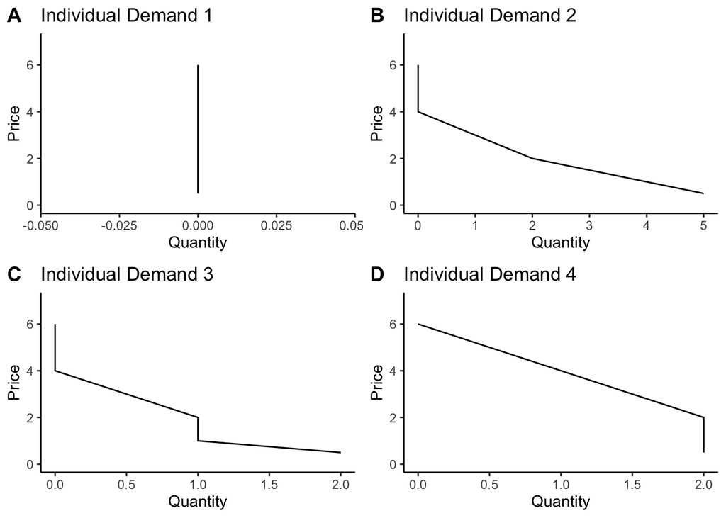

```r
milk1 <- ggplot(data=milk)   +     # Individual demand 1
  geom_line(aes(y = P, x= Q18))  +
  ylim(0, 7) +
  labs(x = "Quantity", y = "Price") +
  ggtitle("Individual Demand 1") + theme_classic()

milk2 <- ggplot(data=milk)   +    # Individual demand 2
  geom_line(aes(y = P, x= Q10))  +
  ylim(0, 7) +
  labs(x = "Quantity", y = "Price") +
  ggtitle("Individual Demand 2")  + theme_classic()

milk3 <- ggplot(data=milk)   +    # Individual demand 3
  geom_line(aes(y = P, x= Q35))  +
  ylim(0, 7) +
  labs(x = "Quantity", y = "Price") +
  ggtitle("Individual Demand 3")  + theme_classic()

milk4 <- ggplot(data=milk)   +    # Individual demand 4
  geom_line(aes(y = P, x= Q50))  +
  ylim(0, 7) +
  labs(x = "Quantity", y = "Price") +
  ggtitle("Individual Demand 4") + theme_classic()

plot_grid(milk1, milk2, milk3, milk4, labels = "AUTO") # Combine demands
```

E’ interessante che una delle domande sia inelastica no? Vi ricordate cosa vi avevo detto? Che per le rette orizzontali e verticali rappresentano assenza di correlazione tra la $x$ e la $y$, ed ineffetti,

```r
cor(milk$P, milk$Q18)
```

```
## [1] NA
```

## Domanda Aggregata

```r
milk$Q_tot <- rowSums(milk[,2:38])
data.frame(prezzo = milk$P, Q_tot = milk$Q_tot)
```

| prezzo | Q_tot |
| --- | --- |
| 6.0 | 4.0 |
| 4.0 | 12.5 |
| 2.0 | 43.5 |
| 1.0 | 72.0 |
| 0.5 | 103.5 |

Questa è la nostra domanda aggregata. Ora possiamo rappresentarla,

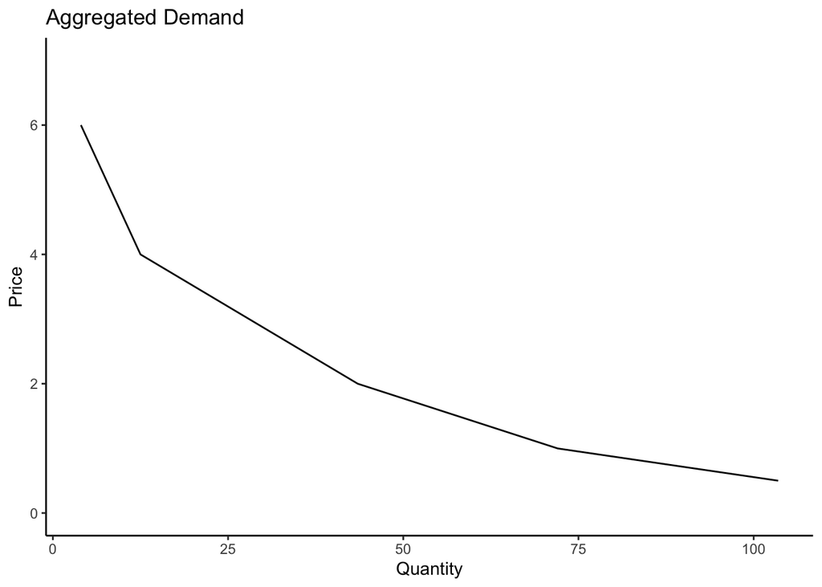

```r
agg_milk <- ggplot(data=milk) +   # Aggregated Demand (On 48 people)
  geom_line(aes(y = P, x= Q_tot))  +
  ylim(0, 7) +
  labs(x = "Quantity", y = "Price") +
  ggtitle("Aggregated Demand") + theme_classic()
agg_milk
```

Ed ecco qui la nostra bella domanda aggregata!!